# Session 3 · Lab 3: From Observation to Manipulation — Causal Inference

- Show All Code
- Hide All Code
- View Source

CRISP-DM Phase 6 — Deployment, with Path E2 Methodology

Author

Prof. Dr. Jörg Schoder

Published

today

## 0.1 Scenario — A Third Memo from Sarah Chen

**Tip📧 Memo from Sarah Chen, VP Marketing — Dominick’s Finer Foods**

Date: 2025-11-22 To: Bridge Cohort

Team,

Lab 1 and Lab 2 made things clearer than I had hoped — and harder. The historical data, even with all the demographic controls Lab 2 added, cannot tell me the *causal* effect of feature advertising on sales. You called this an “OVB problem” and an “identification problem.”

I get it. So my Question 1 stands:

> *If I want the causal effect of advertising, how should I run the study?*

Walk me through the options. What designs are available? What would each cost? What can each promise? I want to come out of this with a clear go/no-go decision on the Q4 budget review.

— Sarah

## 0.2 The bigger picture: when ML meets causal inference

Lab 2 showed that Machine-Learning-style methods (Lasso, Ridge, Elastic Net) can dramatically improve prediction. They cannot, however, deliver causal answers — for two reasons:

1. **They optimise the wrong objective.** ML minimises out-of-sample MSE for $\hat y$. Causal inference targets $\hat\beta$, the structural parameter of the DGP.
2. **They are excellent p-hacking machines.** Their flexibility, uncontrolled, can find a model that fits any preferred result. This is exactly the institutional concern raised in Lab 1’s “Note of Caution” (Spiess 2025).

The literature on the ML / econometrics interface (Athey and Imbens 2019; Mullainathan and Spiess 2017; Spiess 2025) has developed three responses:

- **Path E2 — Study design (this lab’s main path).** Manipulate the DGP through randomisation. The bias is removed *structurally*, not via statistical tricks.
- **Path E2+ — Quasi-experiments.** When manipulation is infeasible, exploit natural variation (DiD, Event Studies, IV).
- **Path E1 + ML — Double Machine Learning.** Use ML for the nuisance components (high-dimensional controls) while protecting the causal estimate via sample-splitting. We touch on this at the end of the lab.

All three responses share one feature: a clear separation between *where the algorithm operates* (prediction, nuisance modeling) and *where the causal claim is made* (the study design). The human in the loop defines this separation — the algorithm does not.

## 0.3 Navigation

| Symbol | Box colour | Meaning | When to read |
| --- | --- | --- | --- |
| ⚠️ | Red (Action Required) | Mandatory tasks, live session | Now |
| 💡 | Green (Tip / Best Practice) | Coding tips, shortcuts | When relevant |
| 📚 | Blue collapsed (Background Theory) | Concepts, theory | Read at home |
| ℹ️ | Blue open (Note) | Short clarifications | In flow |

# 1 Step 0 — Bridge from Lab 2 and Roadmap

In Lab 1 we discovered a confounder. In Lab 2 we accepted that prediction is the only honest objective when the DGP cannot be manipulated. In Lab 3 we change the DGP itself.

**Today’s roadmap:**

| Step | Method | Question it answers |
| --- | --- | --- |
| 1 | **DAGs** | What is the structural reason the OLS estimate is biased? |
| 2 | **A/B-test design** | What study design removes the bias by construction? |
| 3 | **Difference-in-Differences** | When randomisation is impossible, what quasi-experiment helps? |
| 4 | **IV + Double ML (sneak-peek)** | What other identification strategies exist? |
| 5 | **Synthesis + Memo** | What is the answer for Sarah? |

# 2 Step 1 — DAGs as a Tool for Causal Thinking

Recall the structure we discovered in Lab 1: `deal` is a common cause of both `feat` and `logmove`. Drawn as a graph:

[figure not shown]

This is a **directed acyclic graph (DAG)**. We now formalise the language of DAGs and use them to plan causal analyses.

## 2.1 Three building blocks

DAGs are built from three structural patterns. Each has a precise implication for what *conditioning* (i.e. controlling) does to the bias.

### 2.1.1 Confounder (common cause)

```
    Z
   / \
  v   v
  X → Y
```

`Z` causes both `X` and `Y`. The unconditional correlation between `X` and `Y` mixes the causal effect $X \to Y$ with the confounding path $X \leftarrow Z \to Y$. Conditioning on `Z` **blocks** the confounding path and identifies the causal effect.

**This is the `deal` situation from Lab 1.**

### 2.1.2 Mediator (intermediate variable)

```
  X → M → Y
```

`M` is on the causal pathway from `X` to `Y`. Conditioning on `M` **blocks** the indirect effect of `X` on `Y`, leaving only the direct effect. If the question is “what is the total effect of `X` on `Y`?”, we **must not** condition on `M`.

### 2.1.3 Collider (common effect)

```
  X      Y
   \    /
    v  v
     C
```

`C` is caused by both `X` and `Y`. `X` and `Y` are unconditionally independent. But if we condition on `C` (e.g., include it as a control in our regression), we **open** an artificial path between `X` and `Y` — this is **collider bias** or selection bias.

**Warning⚠️ Counter-intuitive: adding controls can HURT**

A common Bachelor-level reflex is: “if in doubt, include more controls.” DAGs show why this is wrong. Conditioning on a collider introduces bias where there was none. Conditioning on a mediator removes part of the effect you want to measure.

The correct rule is the **backdoor criterion** (Pearl 2000): condition on the minimal set of variables that blocks all backdoor paths from treatment to outcome, **without** opening new collider paths.

**Important⚠️ T1: Read the DAG of Sarah’s situation**

The Lab-1 mini-DAG (above) shows `deal → feat → logmove` and `deal → logmove`. Suppose Sarah also wonders whether **shelf position** matters. Imagine the following extended structure:

- `deal` is set by the regional manager based on perceived demand
- `feat` is set by the local store manager, often coordinating with `deal`
- `shelf_position` is also set by the local manager based on `feat`
- `logmove` depends on `feat`, `deal`, and `shelf_position`
1. Draw this extended DAG (paper or whiteboard).
2. Is `shelf_position` a confounder, mediator, or collider for the `feat → logmove` relationship?
3. If we control for `shelf_position` in the regression, what happens to the estimate of $\beta_{\text{feat}}$?

**Note🟢 Discussion (Click to unfold)**

`shelf_position` is on the path `feat → shelf_position → logmove` — it is a **mediator** of part of the `feat` effect.

If we condition on `shelf_position`, we **remove** the part of the advertising effect that operates through better shelf placement. The remaining coefficient on `feat` captures only the *direct* effect (e.g., the flyer-recall effect), not the *total* effect that Sarah cares about for her budget decision.

**Lesson:** the right control set depends on the causal question you are asking. There is no universally “correct” set of controls.

## 2.2 Using DAGs in code: ggdag

**Show code: ggdag example**

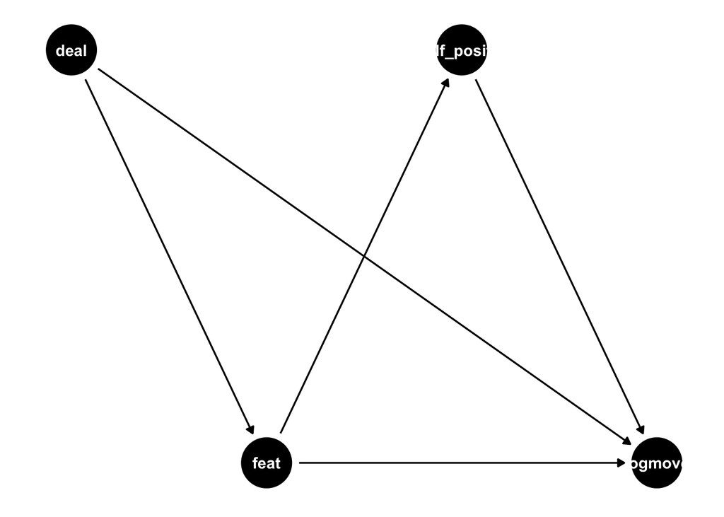

```r
dag <- dagify(
  logmove ~ feat + deal + shelf_position,
  feat ~ deal,
  shelf_position ~ feat,
  coords = list(
    x = c(deal = 1, feat = 2, shelf_position = 3, logmove = 4),
    y = c(deal = 2, feat = 1, shelf_position = 2, logmove = 1)
  )
)

ggdag(dag, layout = "auto") + theme_dag()
```

The `dagitty` package can identify minimal sufficient adjustment sets automatically:

**Show code: dagitty adjustment set**

```r
dag_obj <- dagitty::dagitty(
  'dag {
     deal -> feat
     deal -> logmove
     feat -> logmove
     feat -> shelf_position
     shelf_position -> logmove
   }'
)

dagitty::adjustmentSets(dag_obj, exposure = "feat", outcome = "logmove",
                        effect = "total")
```

```
{ deal }
```

For Sarah’s **total effect** question, the minimal sufficient adjustment set is `{deal}` — confirming what Lab 1 found empirically.

# 3 Step 2 — A/B-test Design: Path E2 in Action

Once we have the DAG, the cleanest solution to OVB is to **break the confounding arrows by randomisation**. If `feat` is assigned at random (not by the store manager), the arrow `deal → feat` is severed.

The DAG of an A/B test:

```
  random_assignment → feat
  deal              → logmove
  feat              → logmove
```

`random_assignment` replaces all other determinants of `feat`. Now `feat` is unconditionally uncorrelated with `deal`, with `shelf_position`, with all unmeasured confounders. The OLS estimate of $\beta_{\text{feat}}$ on randomised data is **unbiased by construction**.

## 3.1 A small simulation

Let us see this empirically. We generate synthetic data with a known true effect, then compare the naive OLS estimate (on observational data) to the OLS estimate on randomised data.

```r
set.seed(42)
n <- 2000

# True parameters
beta_true_feat <- 0.5
beta_true_deal <- 0.4

# Observational DGP: deal causes feat (confounder)
deal_obs <- rbinom(n, 1, 0.3)
feat_obs <- rbinom(n, 1, 0.2 + 0.6 * deal_obs)  # deal increases feat probability
y_obs    <- 5 + beta_true_feat * feat_obs + beta_true_deal * deal_obs +
            rnorm(n, 0, 0.5)

tbl_obs <- tibble(feat = feat_obs, deal = deal_obs, y = y_obs)

# Randomised DGP: feat is independent of deal
deal_rct <- rbinom(n, 1, 0.3)
feat_rct <- rbinom(n, 1, 0.5)  # randomisation: 50/50, independent of deal
y_rct    <- 5 + beta_true_feat * feat_rct + beta_true_deal * deal_rct +
            rnorm(n, 0, 0.5)

tbl_rct <- tibble(feat = feat_rct, deal = deal_rct, y = y_rct)

# Naive OLS on observational data — without deal control
mod_obs_naive <- lm(y ~ feat, data = tbl_obs)

# Naive OLS on RCT data — without deal control
mod_rct_naive <- lm(y ~ feat, data = tbl_rct)

bind_rows(
  tidy(mod_obs_naive) %>% mutate(setting = "Observational"),
  tidy(mod_rct_naive) %>% mutate(setting = "Randomised (A/B)")
) %>%
  filter(term == "feat") %>%
  select(setting, estimate, std.error, p.value) %>%
  mutate(true_value = beta_true_feat,
         bias = round(estimate - beta_true_feat, 3),
         across(where(is.numeric), \(x) round(x, 3))) %>%
  gt() %>%
  gt::tab_options(table.font.size = "12px")
```

| setting | estimate | std.error | p.value | true_value | bias |
| --- | --- | --- | --- | --- | --- |
| Observational | 0.683 | 0.024 | 0 | 0.5 | 0.183 |
| Randomised (A/B) | 0.523 | 0.024 | 0 | 0.5 | 0.023 |

**Important⚠️ T2: Read the simulation output**

1. What is the bias of the naive OLS estimate on observational data?
2. What is the bias on the randomised data?
3. Why does randomisation work, even though we did *not* control for `deal` in either regression?

**Note🟢 Discussion (Click to unfold)**

1. On observational data, the naive OLS estimate is biased upward (overstates the true `feat` effect) because it absorbs the `deal` effect that operates through the correlation `deal → feat`.
2. On randomised data, the estimate is unbiased — within sampling noise it equals the true value 0.5.
3. Randomisation **breaks the arrow** `deal → feat` by construction. `feat` is now uncorrelated with `deal` (and with every other confounder, observed or unobserved). The OLS estimate of $\beta_{\text{feat}}$ is identified from the experimental variation alone.

**This is the gold standard for Path E2.** It does not require us to *measure* every confounder — randomisation handles all of them at once, including unobservable ones.

## 3.2 Practical considerations

A/B tests in retail are operationally non-trivial:

- **Unit of randomisation.** Store-week, store-level, or brand × store-week? Each choice has implications for power and for what causal estimand we identify.
- **Spillover.** If neighbouring stores share customers, treating store A while controlling store B contaminates the control.
- **Compliance.** A randomly assigned `feat = 1` may not be implemented uniformly by the local manager.
- **Cost.** Sarah needs board approval to *not* advertise in some stores during Q4.

For Sarah’s purposes, a **cluster-randomised store-level A/B test** in non-peak weeks is realistic and would identify the total effect of `feat` cleanly.

# 4 Step 3 — Difference-in-Differences and Event Studies

When randomisation is impossible (politically, operationally, or ethically), **quasi-experimental designs** exploit natural variation. The classical example: a policy change rolls out at different times across regions, giving us “treated” and “control” groups whose pre-treatment trends should be parallel.

## 4.1 The DiD logic

Suppose the regional office expanded the advertising programme in Chicago stores starting week 80, while Suburb stores received no change. The DiD estimator compares:

$$\hat\delta_{\text{DiD}} = \big(\bar Y_{\text{Chicago}, \text{post}} - \bar Y_{\text{Chicago}, \text{pre}}\big) - \big(\bar Y_{\text{Suburb}, \text{post}} - \bar Y_{\text{Suburb}, \text{pre}}\big)$$

The key identifying assumption is **parallel trends**: in the absence of treatment, the Chicago and Suburb sales would have evolved similarly.

## 4.2 A synthetic DiD example

```r
set.seed(1)

# Treatment: a subset of stores receives an intensified ad campaign starting week 80
treated_stores <- tbl_stores %>% pull(store) %>% unique() %>% sample(20)

tbl_did <- tbl_stores %>%
  mutate(
    treated = as.numeric(store %in% treated_stores),
    post    = as.numeric(week >= 80),
    treat_post = treated * post,
    # synthetic treatment effect: log-sales rise by 0.15 in treated × post
    logmove_simulated = logmove + 0.15 * treat_post
  )

# DiD regression with two-way fixed effects
mod_did <- fixest::feols(logmove_simulated ~ treat_post | store + week,
                         data = tbl_did)

# extract the DiD coefficient
tidy(mod_did) %>%
  filter(term == "treat_post") %>%
  mutate(across(where(is.numeric), \(x) round(x, 3))) %>%
  gt() %>%
  gt::tab_options(table.font.size = "12px")
```

[output not shown]

## 4.3 A recent critique: TWFE with staggered adoption

The classical two-way-fixed-effects (TWFE) regression we just ran has been shown to misbehave when treatment timing varies across units (staggered rollout). (Borusyak, Jaravel, and Spiess 2024) demonstrate that TWFE implicitly compares newly-treated units to already-treated units, producing **negative weights** and **aggregation biases**.

**The remedy: imputation-based DiD.** Model the counterfactual outcome for control observations explicitly, then compute treatment effects only for treated observations:

1. Fit a model on never-treated and not-yet-treated observations
2. Predict counterfactual outcomes for treated observations
3. Treatment effect = actual − counterfactual

This **separates** the modeling of the control trend from the estimation of the causal effect — a recurring pattern in modern causal inference, and again an instance of the Spiess-style institutional argument (Spiess 2025): estimation and selection / modeling are kept in separate “rooms” to protect the causal claim.

```r
# Sketch (not run in this lab; uses didimputation package)
library(didimputation)

did_imp <- did_imputation(
  data = tbl_did,
  yname = "logmove_simulated",
  gname = "first_treated_week",  # week at which each unit was first treated
  tname = "week",
  idname = "store"
)
summary(did_imp)
```

The `didimputation` package implements (Borusyak, Jaravel, and Spiess 2024) directly. Full treatment in →ER017.

## 4.4 Event-study designs as the dynamic extension

DiD gives a **single average** treatment effect. Event-study designs are the dynamic extension: they trace how the treatment effect evolves *over time* relative to the treatment date. Each “lead” (period before treatment) and “lag” (period after) receives its own coefficient.

| Approach | What it estimates | When to use |
| --- | --- | --- |
| **DiD** | Average effect post vs. pre | Single sharp policy change |
| **Event study** | Dynamic profile of effect | When timing of effect matters |
| **Synthetic control** | Effect for one treated unit | Single unit, many controls |
| **Imputation DiD** | Robust to staggered adoption | Multiple treatment timings |

The Event-Study design pre-treatment coefficients also provide a **direct test of parallel trends**: if they are all close to zero, the parallel-trends assumption is empirically supported.

**Note📚 Background: How an event study differs from DiD**

In a classical DiD with treatment at time $t^*$, we estimate one coefficient: the average effect post-$t^*$ relative to pre-$t^*$.

In an event study, we estimate one coefficient *per event time*. If the event is at week 80 and we observe 10 weeks before and 10 weeks after, we estimate 21 coefficients (or 20 with one omitted as reference):

$$Y_{it} = \alpha_i + \lambda_t + \sum_{\tau = -10}^{10} \beta_\tau \mathbb{1}\{t - t^*_i = \tau\} + \varepsilon_{it}$$

The plot of $\{\hat\beta_\tau\}$ against $\tau$ shows:

- The pre-treatment coefficients should hover around zero (parallel trends test)
- The post-treatment coefficients show how the effect builds up, peaks, and possibly decays

Event studies are now standard practice for evaluating policy interventions where timing matters, and they are the natural host for the imputation-style estimator from (Borusyak, Jaravel, and Spiess 2024).

# 5 Step 4 — IV and Double Machine Learning (Sneak-Peek)

## 5.1 Instrumental variables — when neither randomisation nor DiD applies

Sometimes the causal question is about a continuous variable (price, for example) and we have no natural experiment. Then we need an **instrument** $Z$ that:

1. Is correlated with the treatment $D$ (relevance)
2. Affects the outcome $Y$ only through $D$ (exclusion restriction)

For Sarah’s setting, **competitor distance** (`cpdist5` in the demographics) could plausibly serve as an instrument for price: stores far from competitors face less price pressure and charge higher prices, but `cpdist5` affects sales only via prices, not directly.

```r
library(AER)
# IV estimation: log(price) instrumented by cpdist5
mod_iv <- ivreg(logmove ~ feat + log(price) + brand |
                  feat + cpdist5 + brand,
                data = tbl_full)
summary(mod_iv, diagnostics = TRUE)
```

The Lab-1 elasticity estimate of $-2.9$ may be confounded by unobserved demand shocks (high-demand stores can charge higher prices). The IV estimate — using `cpdist5` as exogenous variation in price — would give a cleaner causal elasticity.

**Full treatment in →ER017.**

## 5.2 Double Machine Learning — when controls are high-dimensional

**Double Machine Learning** (Chernozhukov et al. 2018) solves this with three steps:

1. **Use ML to model the nuisance parts** of the data:
   - $\hat E[Y \mid X]$: how outcome relates to controls
   - $\hat E[D \mid X]$: how treatment relates to controls
2. **Residualise.** Compute $\tilde Y = Y - \hat E[Y \mid X]$ and $\tilde D = D - \hat E[D \mid X]$.
3. **Final causal estimate.** Regress $\tilde Y$ on $\tilde D$. The coefficient is the causal effect.

**The crucial twist: cross-fitting.** Steps 1 and 2 use *one half* of the data; step 3 uses the *other half*. This sample-splitting (Spiess 2025) prevents the ML’s flexibility from leaking into the causal estimate. Without it, the ML would fit noise, and the residual correlation in step 3 would be biased toward the researcher’s preferred answer.

This is the operative answer to the institutional argument from Lab 1’s “Note of Caution”: ML for nuisance modeling, with sample-splitting protecting the causal estimate.

```r
# Conceptual code — full implementation in ER017
library(DoubleML)
library(mlr3)

data <- DoubleMLData$new(tbl_full,
  y_col  = "logmove",
  d_cols = "feat",
  x_cols = c("log_price", "age60", "income", "educ", "ethnic",
             "hhlarge", "workwom", "hval150", "sstrdist",
             "sstrvol", "cpdist5", "cpwvol5"))

ml_g <- lrn("regr.ranger")  # Random Forest for E[Y|X]
ml_m <- lrn("regr.ranger")  # Random Forest for E[D|X]

dml_model <- DoubleMLPLR$new(data, ml_g, ml_m, n_folds = 5)
dml_model$fit()
dml_model$summary()
```

The result: a causal estimate of $\beta_{\text{feat}}$ that uses ML’s flexibility for the controls but preserves unbiasedness for the treatment effect.

**Verweis auf ER017** for full operational treatment with `DoubleML`.

## 5.3 A note on the FE perspective (→ ER117)

Lab 1’s `tbl_s114` analysis was implicitly a **within-store** analysis: by working with one store, we held all store-specific heterogeneity constant. Fixed-effects panel models generalise this to all 83 stores while still removing store-level confounders.

```r
library(fixest)
mod_fe <- feols(logmove ~ feat + deal + log(price) | store + week,
                data = tbl_stores)
summary(mod_fe)
```

Fixed effects remove **all time-invariant store-level confounders** (manager identity, neighbourhood demographics, shelf-space layout). DiD and Event Studies are essentially FE models with an additional *time-of-treatment* dimension. Full treatment in →ER117.

# 6 Step 5 — Synthesis and Memo for Sarah

The three labs together answer Sarah’s two questions in a structured way:

| Question | Path | Method (this module) | What was achieved |
| --- | --- | --- | --- |
| Q1 (causal effect) | E1 | Lab 1 OLS + diagnostics | Bias diagnosed (`deal` confounder) |
| Q1 (causal effect) | E1+P | Lab 2 Lasso with controls | Bias confirmed structural, not solvable by controls |
| Q1 (causal effect) | E2 | Lab 3 A/B test design | Clean identification possible — design required |
| Q1 (causal effect) | E2+ | Lab 3 DiD / Event Study | Quasi-experimental fallback if A/B test infeasible |
| Q1 (causal effect) | E1+ML | Lab 3 Double ML | High-dimensional controls + unbiased estimate |
| Q2 (prediction) | P | Lab 2 cv-Lasso with demographics | Inventory tool ready, OOS RMSE quantified |

**Important⚠️ T_final: Final translator memo**

Draft Sarah’s final memo. Cover:

1. Which design would you recommend for Q4 measurement of the advertising effect? A/B test, DiD, or DML? Argue based on: feasibility, cost, validity, and what causal claim each supports.
2. If Sarah’s board insists on having a recommendation *now* (before any experiment), what is the *best estimate* you can provide from observational data, and how do you communicate its limitations honestly?
3. Reflect: how does the Lab-1 “Note of Caution” argument apply to the memo you are writing? What does the institutional restriction of unbiasedness mean for *you* as the analyst?

**5-8 sentences per question. Business language.**

## 6.1 A note on the human in the loop

Across Lab 1, Lab 2, and Lab 3, you have seen three roles for the analyst:

- **Lab 1 (Path E1):** the analyst diagnoses model misspecification
- **Lab 2 (Path P):** the analyst tunes regularisation to optimise prediction
- **Lab 3 (Path E2):** the analyst designs the study to enable causal identification

In all three roles, the algorithm operates in a sub-space defined by the analyst. The algorithm does not choose the question, does not validate the assumptions, does not bear responsibility for the recommendation. **The human is in the loop.** Sarah Chen’s memos do not come from `lm()` or `cv.glmnet()` or `DoubleML$fit()` — they come from your judgment, informed by the algorithms’ output.

This is the central professional skill of the modern data scientist in business: not the technical mastery of any one tool, but the ability to map a business question onto the right methodological path, validate the underlying assumptions, and communicate the honest answer — including its limitations.

# 7 Bonus — For independent study

## 7.1 ⚠️ B1: Collider-bias simulation

Construct a small DAG where `X → C` and `Y → C` (C is a collider). Generate data accordingly. Show that:

1. The unconditional regression of `Y` on `X` gives an unbiased estimate (which is zero, by construction).
2. Conditioning on `C` (including it as a control) introduces a spurious correlation between `X` and `Y`.

This is the empirical version of the warning in Step 1.

## 7.2 ⚠️ B2: Power analysis for a store-level A/B test

For Sarah’s planned A/B test:

1. Given the variability of `logmove` in `tbl_stores`, how many store-weeks per arm are needed to detect an effect of size $\delta = 0.10$ at 80% power and $\alpha = 0.05$?
2. How does the required sample change if Sarah wants to detect a smaller effect ($\delta = 0.05$)?
3. What does this imply for the **duration** of the A/B test given the 83 available stores?

Use `pwr::pwr.t.test()` or `pwr::pwr.f2.test()`.

## 7.3 ⚠️ B3: Event study on the synthetic DiD data

Re-fit the DiD example from Step 3 as an event study:

1. Replace the single `treat_post` indicator with a set of indicators for $\tau \in \{-10, -9, \ldots, +10\}$.
2. Plot the coefficient profile.
3. Are the pre-treatment coefficients consistent with parallel trends?

## 7.4 ⚠️ B4: Hausman test for IV validity

Use the IV setup from Step 4. Run a Hausman test comparing OLS and IV estimates:

1. What does the Hausman test tell you about whether `log(price)` is endogenous?
2. What does it *not* tell you (hint: about the validity of the instrument itself)?

## 7.5 ⚠️ B5: Sensitivity analysis for DiD parallel trends

The parallel-trends assumption is **untestable** for the post-treatment period (by construction we never see it). But (Rambachan and Roth 2023) developed bounds-based sensitivity analyses: “how much would parallel trends have to be violated to overturn my conclusion?”

1. Conceptually: why is this question more useful than a yes/no test of the assumption?
2. Sketch (in prose) how you would communicate the result to Sarah’s board.

# 8 What comes next (→ER017)

| Module | What it adds |
| --- | --- |
| **Time Series & Causal Inference** | Full operational treatment of DiD, Event Studies, IV, Synthetic Control, DML |
| **Panel Data Methods** | Fixed effects, random effects, GMM, dynamic panels |

The DGP framework from Session 3 carries through both modules: the question is always *what is the DGP*, *which path approaches it*, and *what does our chosen method actually identify*.

## References

Athey, Susan, and Guido W. Imbens. 2019. “Machine Learning Methods That Economists Should Know About.” *Annual Review of Economics* 11 (1): 685–725. https://doi.org/10.1146/annurev-economics-080217-053433.

Borusyak, Kirill, Xavier Jaravel, and Jann Spiess. 2024. “Revisiting Event-Study Designs: Robust and Efficient Estimation.” *The Review of Economic Studies* 91 (6): 3253–85. https://doi.org/10.1093/restud/rdae007.

Chernozhukov, Victor, Denis Chetverikov, Mert Demirer, Esther Duflo, Christian Hansen, Whitney Newey, and James Robins. 2018. “Double/Debiased Machine Learning for Treatment and Structural Parameters.” *The Econometrics Journal* 21 (1): C1–68. https://doi.org/10.1111/ectj.12097.

Mullainathan, Sendhil, and Jann Spiess. 2017. “Machine Learning: An Applied Econometric Approach.” *Journal of Economic Perspectives* 31 (2): 87–106. https://doi.org/10.1257/jep.31.2.87.

Pearl, Judea. 2000. *Causality: Models, Reasoning, and Inference*. Cambridge, U.K. ; New York: Cambridge University Press.

Rambachan, Ashesh, and Jonathan Roth. 2023. “A More Credible Approach to Parallel Trends.” *Review of Economic Studies* 90 (5): 2555–91. https://doi.org/10.1093/restud/rdad018.

Spiess, Jann. 2025. “Optimal Estimation When Researcher and Social Preferences Are Misaligned.” *Econometrica* 93 (5): 1779–1810. https://doi.org/10.3982/ECTA18640.